# SIR Models and US Covid Data

Chris H Wilson

3/26/2020

# Background and Goals

As I write this, the United States is currently in an early, rapid, *exponential* phase of growth of the Covid-19 disease caused by the SARS-CoV2 virus. In an earlier piece, I explained the derivation of a commonly discussed quantity “$R_0$”, and derived the foundational equations of epidemiology from first principles, the so-called SIR model (https://rpubs.com/chwilson101/587211). In this essay, I want to discuss how this model framework informs on what we are seeing with Covid-19. In particular, I will show how surprisingly well the data so far cohere with our theoretical expectations, and then I will fit some models to data and generate *short term* forecasts on that basis.

*Long term*, there are too many unknowns to sling around confident forecasts. Our uncertainties are not just in the relevant parameters, but in how to structurally formulate models that accomodate enough of the real world to be useful. As in climate science, a chief source of uncertainty hinges on human actions. What kind of further control measures will be imnplemented and with what degree of competence? Will people in their communities go along with interventions or try to skirt them? As I concluded in my last piece, **the history of this pandemic is ours to write**. It is not written into the equations or math that follow.

# Current Situation

First, let’s look at a time series of confirmed positive cases of Covid-19 in the United States, accompanied by the corresponding deaths (Fig. 1).

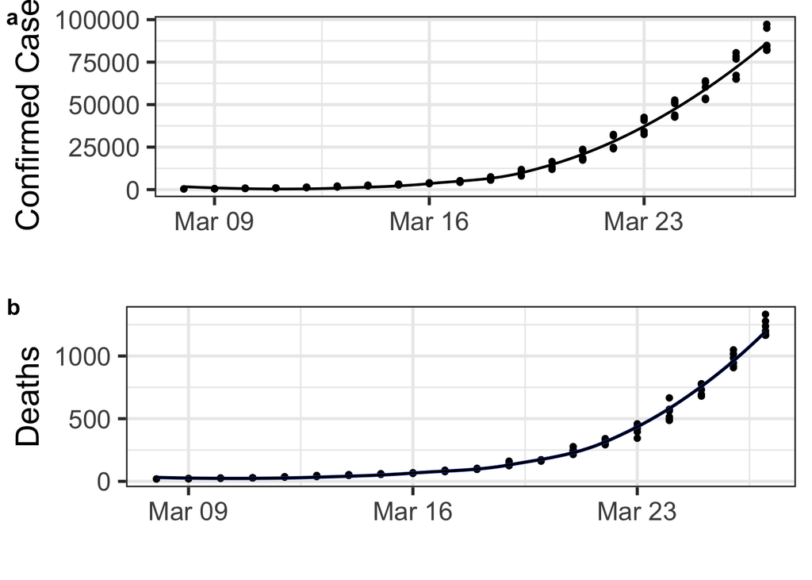

$\textit{Figure 1: Covid-19 in the United States. a) confirmed cases over time, and b) deaths over time. Data courtesy of: http://coronavirusapi.com/}$

What we are seeing is clearly an exponential increase in both confirmed cases over time, as well as in mortality (deaths). There has also been a substantial problem in that the US response vis a vis testing has lagged other more competent nations, due to our political dysfunction. Here we see a plot of tests over time, normalized by population (Fig. 2):

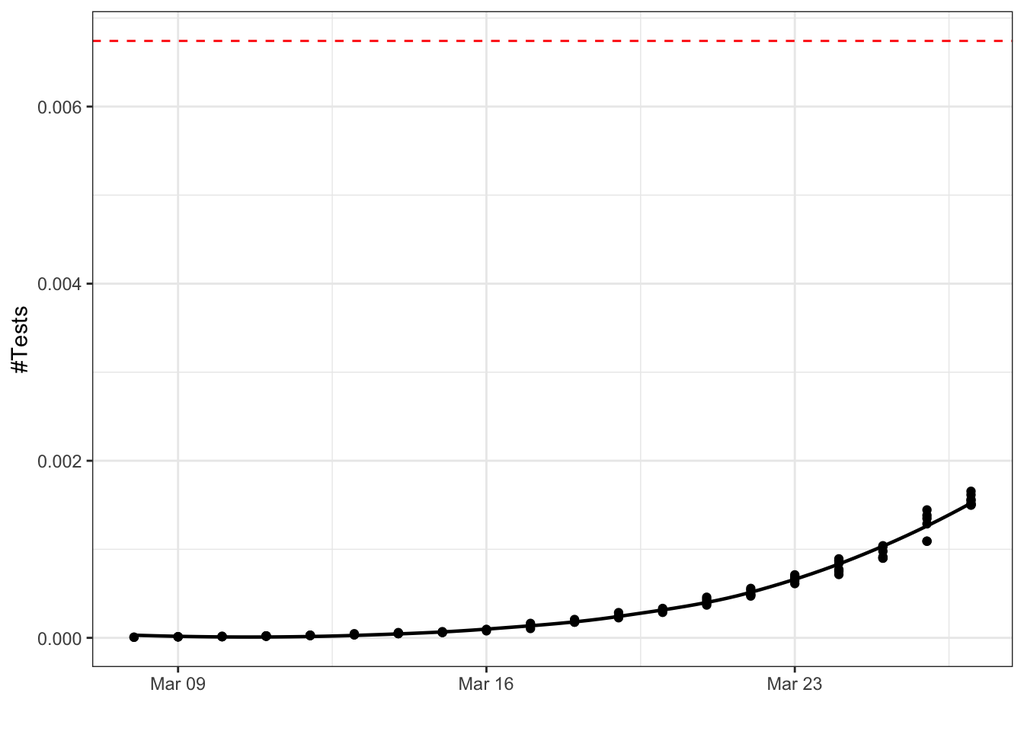

$\textit{Figure 2: Covid-19 testing in the United States normalized by population,compared to the current status in South Korea (as of March 24th 2020)}$

Clearly, we have a lot of catching up to do in our testing coverage before we can really get this pandemic under control. In addition to prioritization of resources, greater testing coverage will also enable a vigorous ‘test and trace’ strategy, which is going to be crucial for transitioning out of lockdowns safely.

# Understanding the Current Dynamics

Organizational and political desiderata aside, Fig. 1 clearly shows that we are still in the exponentially increasing phase of this infection. Returning to our SIR equations briefly,

$$\tag {1} \frac {dS}{dt} = - R_0 \nu I \frac{S}{N}$$
$$\tag {2} \frac {dI}{dt} = R_0 \nu I \frac{S}{N} - \nu I$$
$$\tag {3} \frac {dR}{dt} = \nu I$$

$$\tag {4} \frac {dI}{dt} = \nu (R_0-1) I$$
which is clearly of exponential form, with exponential growth coefficient equal to $\nu (R_0-1)$. Qualitatively then, what we see in Fig. 1 makes sense and coheres with theoretical expectations. In fact, it is kind of surprising how well the data at the national level follow this smooth exponential curve. To illustrate, let us look at a simple OLS linear regression model where we take the $log(cases)$ as our response variable, and $day$ as our predictor variable (Table 1)

```
## lm(formula = log(positive) ~ day, data = UScovid)
##             coef.est coef.se
## (Intercept) 5.69     0.03
## day         0.29     0.00
## ---
## n = 95, k = 2
## residual sd = 0.14, R-Squared = 0.99
```

The regression formula is:

$$\tag {5} log(positive_i) = \beta_0 + \beta_1 day_i + \epsilon_i$$
As we can see in Table 1, our estimates for $beta_0$ and $beta_1$ are super precise, and the overall $R^2$ of the model is 0.99! Mathematically, regressing the log() of a response variable is equivalent to fitting an exponential curve, since equation 5 can be re-written as,

$$\tag {6} positive_i = e^{(\beta_0 + \beta_1 day_i)} + \epsilon_i$$
That being the case, we can draw a simple curve fit using our fitted parameter estimates and then overlay our data

$$\tag {7} positive_i = e^{5.69}e^{0.29 day_i}$$
which looks like,

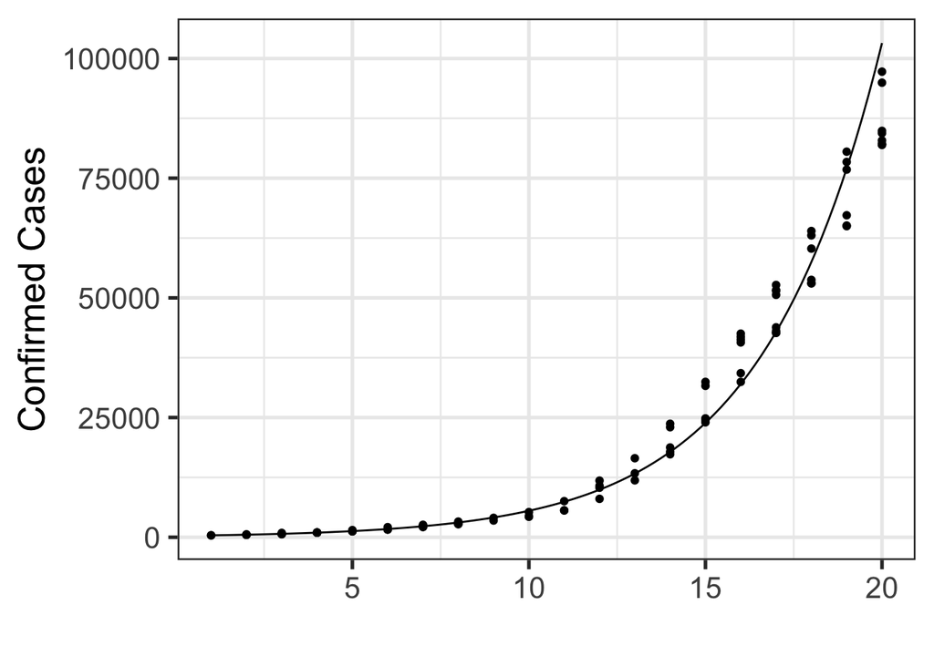

$\textit{Figure 3: Fitted exponential model against national Covid-19 positive cases}$

We can see in Fig. 3 that our naive, basic exponential model fits pretty well. However, there are definitely some qualitative discprepancies to note. First, the model is underpredicting days 14-18, and then overpredicting by the last two days (19-20). This suggests that the curvature is too great, and thus that our exponent estimate is likely *too high*. There are a couple possible explanations for this. First is that we need to account for the widespread expansion of testing. Second, we could be entering a phase of the epidemic growth where exponential behavior begins to give way to more linear-ish and eventually diminishing towards a peak.

```
## lm(formula = log(deaths) ~ day, data = UScovidMort)
##             coef.est coef.se
## (Intercept) 2.21     0.04
## day         0.24     0.00
## ---
## n = 85, k = 2
## residual sd = 0.13, R-Squared = 0.99
```

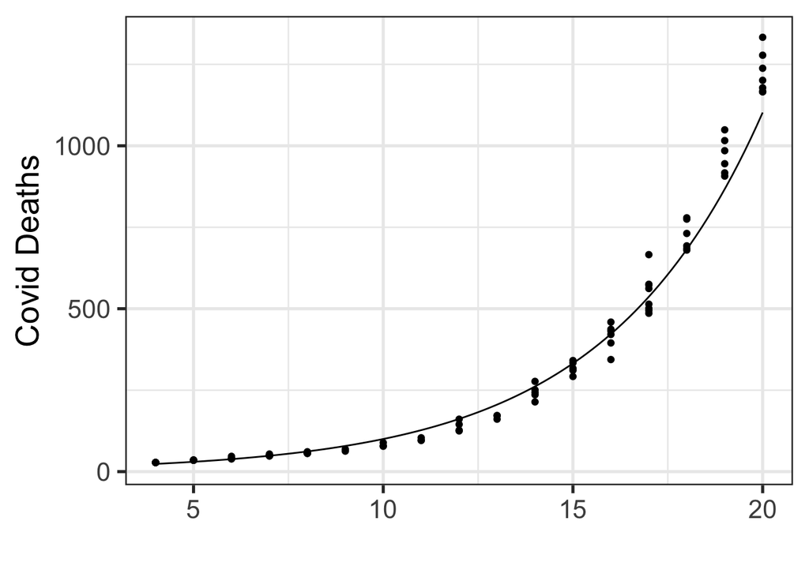

$\textit{Figure 4: Fitted exponential model against national Covid-19 deaths}$

Once again we have exceedingly high R^2 and precision in these estimates. Interestingly, if anything, the curvature is now too low, and hence our exponential model extrapolation is too conservative…**for the time being**.